# Research Question 1

Do sites differ in objectively measured personal light exposure? If so, does an individual’s behaviour and micro-environment have a stronger effect than site?

Author

Johannes Zauner

## Preface

This document contains the analysis for Research Question 1, as defined in the [preregistration](https://aspredicted.org/te3zw2.pdf).

> **Research Question 1**:  
> Do sites differ in objectively measured personal light exposure? If so, does an individual’s behaviour and micro-environment have a stronger effect than site?

> *H1*: There is a significant difference in personal light-exposure metrics across sites, even after accounting for latitude and photoperiod.

> *H2*: The variance of personal light exposure patterns (hourly geometric mean of melanopic EDI) by participants within sites is greater than the variance between sites.

## Setup

In this section, we load in the preprocessed and prepared data, site data, and load required packages.

```
Setup
```

```r
library(tidyverse)
library(melidosData)
library(LightLogR)
library(mgcv)
library(lme4)
library(performance)
library(cowplot)
library(ggridges)
library(broom)
library(broom.mixed)
library(gt)
library(performance)
library(glmmTMB)
library(gtsummary)
source("scripts/fitting.R")
source("scripts/summaries.R")
```

```
Load data
```

```r
load("data/metrics_glasses.RData")
metrics <- metrics_glasses
H1 <- "Hypothesis: There is a significant difference in personal light-exposure metrics across sites, even after accounting for latitude and photoperiod."
sig.level <- 0.05

#for chest:
# load("data/metrics_chest.RData")
# metrics <- metrics_chest
# melidos_cities <- melidos_cities[names(melidos_cities)!="MPI"]
```

## Hypothesis 1

### Details

Hypothesis 1 states:

> There is a significant difference in personal light-exposure metrics across sites, even after accounting for latitude and photoperiod.

*Type of model:* LMM

*Base formula:* $\text{Metric} \sim \text{Site} + \text{Photoperiod} + (1|\text{Site}:\text{Participant})$

*Additional notes:* - For dynamics-based metrics LM without Participant random effect. - Because latitude and site are each individual values per site (i.e., each site has its unique latitude), they have to be modelled separately and will be compared via AIC.

*False-discovery-rate correction:* 17 (number of metrics that are compared)

### Preparation

```
Model setup based on distribution
```

```r
model_tbl <- tibble::tribble(
    ~name, ~engine, ~ response, ~family,
    "interdaily_stability", "lm", "qlogis(metric)", gaussian(),
    "intradaily_variability", "lm", "metric", gaussian(),
    "Mean", "lmer", "log_zero_inflated(metric)", gaussian(),
    "dose", "lmer", "log_zero_inflated(metric)", gaussian(),
    "MDER", "lmer", "metric", gaussian(),
    "darkest_10h_mean", "lmer", "log_zero_inflated(metric)", gaussian(),
    "brightest_10h_mean", "lmer", "log_zero_inflated(metric)", gaussian(),
    "duration_above_1000", "glmmTMB", "metric", tweedie(link = "log"),
    "duration_above_250", "lmer", NA, gaussian(),
    "duration_below_10", "lmer", NA, gaussian(),
    "duration_below_1", "lmer", NA, gaussian(),
    "duration_above_250_wake", "glmmTMB", "metric", tweedie(link = "log"),
    "duration_below_10_pre-sleep", "glmmTMB", "metric", tweedie(link = "log"),
    "duration_below_1_sleep", "glmmTMB", "metric", tweedie(link = "log"),
    "period_above_250", "lmer", "log_zero_inflated(metric)", gaussian(),
    "brightest_10h_midpoint", "lmer", "metric", gaussian(),
    "brightest_10h_onset", "lmer", NA, gaussian(),
    "brightest_10h_offset", "lmer", NA, gaussian(),
    "darkest_10h_midpoint", "lmer", "metric", gaussian(),
    "darkest_10h_onset", "lmer", NA, gaussian(),
    "darkest_10h_offset", "lmer", NA, gaussian(),
    "mean_timing_above_250", "lmer", "metric", gaussian(),
    "first_timing_above_250", "lmer", "metric", gaussian(),
    "last_timing_above_250", "lmer", "metric", gaussian()
  )
```

```
Formula setup for inference
```

```r
metrics <-
  metrics |>
  mutate(H1_1 = case_when(type == "participant" ~
                                  "~ site + photoperiod",
                                type == "participant-day" ~
                                  "~ site + photoperiod + (1| site:Id)"),
         H1_0 = case_when(type == "participant" ~
                                   "~ 1 + photoperiod",
                                 type == "participant-day" ~
                                  "~ 1 + photoperiod + (1| site:Id)"),
         H1_lat = case_when(type == "participant" ~
                                   "~ lat + photoperiod",
                                 type == "participant-day" ~
                                  "~ lat + photoperiod + (1|site:Id)"),
         # H1_phot = case_when(type == "participant" ~
         #                           "~ photoperiod",
         #                         type == "participant-day" ~
         #                          "~ photoperiod + (1|site:Id)"),
         H1_rand = case_when(type == "participant" ~
                                   NA,
                                 type == "participant-day" ~
                                  "~ 1 + photoperiod + (1|site/Id)")
         ) |>
  left_join(model_tbl, by = "name")

H1_formulas <-  names(metrics) |> subset(grepl("H1_", names(metrics)))

metrics <-
  metrics |> relocate(all_of(H1_formulas), .after = family)
H1_fdr_n <- metrics |> filter(!is.na(response)) |> nrow()
```

Hypothesis 1: metric model specifications

Hypothesis: There is a significant difference in personal light-exposure metrics across sites, even after accounting for latitude and photoperiod.

|  | Name | Type | Engine | Response | Family | H1 1<sup>1</sup> | H1 0<sup>1</sup> | H1 lat<sup>2</sup> | H1 rand<sup>2</sup> |
| --- | --- | --- | --- | --- | --- | --- | --- | --- | --- |
| duration |  |  |  |  |  |  |  |  |  |
| 1 | Duration above 1000 | participant-day | glmmTMB | metric | tweedie | ~ site + photoperiod + (1\| site:Id) | ~ 1 + photoperiod + (1\| site:Id) | ~ lat + photoperiod + (1\|site:Id) | ~ 1 + photoperiod + (1\|site/Id) |
| 2 | Duration above 250 wake | participant-day | glmmTMB | metric | tweedie | ~ site + photoperiod + (1\| site:Id) | ~ 1 + photoperiod + (1\| site:Id) | ~ lat + photoperiod + (1\|site:Id) | ~ 1 + photoperiod + (1\|site/Id) |
| 3 | Duration below 10 pre-Sleep | participant-day | glmmTMB | metric | tweedie | ~ site + photoperiod + (1\| site:Id) | ~ 1 + photoperiod + (1\| site:Id) | ~ lat + photoperiod + (1\|site:Id) | ~ 1 + photoperiod + (1\|site/Id) |
| 4 | Duration below 1 sleep | participant-day | glmmTMB | metric | tweedie | ~ site + photoperiod + (1\| site:Id) | ~ 1 + photoperiod + (1\| site:Id) | ~ lat + photoperiod + (1\|site:Id) | ~ 1 + photoperiod + (1\|site/Id) |
| 5 | Period above 250 | participant-day | lmer | log_zero_inflated(metric) | gaussian | ~ site + photoperiod + (1\| site:Id) | ~ 1 + photoperiod + (1\| site:Id) | ~ lat + photoperiod + (1\|site:Id) | ~ 1 + photoperiod + (1\|site/Id) |
| dynamics |  |  |  |  |  |  |  |  |  |
| 6 | Interdaily stability | participant | lm | qlogis(metric) | gaussian | ~ site + photoperiod | ~ 1 + photoperiod | ~ lat + photoperiod |  |
| 7 | Intradaily variability | participant | lm | metric | gaussian | ~ site + photoperiod | ~ 1 + photoperiod | ~ lat + photoperiod |  |
| exposure history |  |  |  |  |  |  |  |  |  |
| 8 | Dose | participant-day | lmer | log_zero_inflated(metric) | gaussian | ~ site + photoperiod + (1\| site:Id) | ~ 1 + photoperiod + (1\| site:Id) | ~ lat + photoperiod + (1\|site:Id) | ~ 1 + photoperiod + (1\|site/Id) |
| level |  |  |  |  |  |  |  |  |  |
| 9 | Mean | participant-day | lmer | log_zero_inflated(metric) | gaussian | ~ site + photoperiod + (1\| site:Id) | ~ 1 + photoperiod + (1\| site:Id) | ~ lat + photoperiod + (1\|site:Id) | ~ 1 + photoperiod + (1\|site/Id) |
| 10 | Brightest 10h mean | participant-day | lmer | log_zero_inflated(metric) | gaussian | ~ site + photoperiod + (1\| site:Id) | ~ 1 + photoperiod + (1\| site:Id) | ~ lat + photoperiod + (1\|site:Id) | ~ 1 + photoperiod + (1\|site/Id) |
| 11 | Darkest 10h mean | participant-day | lmer | log_zero_inflated(metric) | gaussian | ~ site + photoperiod + (1\| site:Id) | ~ 1 + photoperiod + (1\| site:Id) | ~ lat + photoperiod + (1\|site:Id) | ~ 1 + photoperiod + (1\|site/Id) |
| spectrum |  |  |  |  |  |  |  |  |  |
| 12 | MDER | participant-day | lmer | metric | gaussian | ~ site + photoperiod + (1\| site:Id) | ~ 1 + photoperiod + (1\| site:Id) | ~ lat + photoperiod + (1\|site:Id) | ~ 1 + photoperiod + (1\|site/Id) |
| timing |  |  |  |  |  |  |  |  |  |
| 13 | Brightest 10h midpoint | participant-day | lmer | metric | gaussian | ~ site + photoperiod + (1\| site:Id) | ~ 1 + photoperiod + (1\| site:Id) | ~ lat + photoperiod + (1\|site:Id) | ~ 1 + photoperiod + (1\|site/Id) |
| 14 | Darkest 10h midpoint | participant-day | lmer | metric | gaussian | ~ site + photoperiod + (1\| site:Id) | ~ 1 + photoperiod + (1\| site:Id) | ~ lat + photoperiod + (1\|site:Id) | ~ 1 + photoperiod + (1\|site/Id) |
| 15 | First timing above 250 | participant-day | lmer | metric | gaussian | ~ site + photoperiod + (1\| site:Id) | ~ 1 + photoperiod + (1\| site:Id) | ~ lat + photoperiod + (1\|site:Id) | ~ 1 + photoperiod + (1\|site/Id) |
| 16 | Last timing above 250 | participant-day | lmer | metric | gaussian | ~ site + photoperiod + (1\| site:Id) | ~ 1 + photoperiod + (1\| site:Id) | ~ lat + photoperiod + (1\|site:Id) | ~ 1 + photoperiod + (1\|site/Id) |
| 17 | Mean timing above 250 | participant-day | lmer | metric | gaussian | ~ site + photoperiod + (1\| site:Id) | ~ 1 + photoperiod + (1\| site:Id) | ~ lat + photoperiod + (1\|site:Id) | ~ 1 + photoperiod + (1\|site/Id) |

Confirmatory analysis will use a p-value correction through the false-discovery rate for n=17 comparisons  
<sup>1</sup> These are the models used for the confirmatory analysis. Each H1 1 and H1 0 pair are compaired with likelihood-ratio tests to determine whether site is meaningful  
<sup>2</sup> These models will be checked via AIC against H1 1 to see whether there is indeed a site difference beyond the specific difference in the model. Also, this model is compared against the H1 0 model

```
Formula creation
```

```r
metrics <-
  metrics |>
  mutate(across(all_of(H1_formulas),
                \(x) map2(x, response, \(y,z) make_formula(z, y))
                )
         )
```

```
Offset zero-values in mixed gamma models
```

```r
 metrics <-
  metrics |>
  mutate(data = map2(data, engine, \(data, engine) {
    if(engine == "glmer") {
      data |> mutate(metric = metric + 0.1)
    } else data
  }))
```

### Analysis

#### Fit models

```
Model fit
```

```r
metrics <-
  metrics |>
  mutate(
    across(all_of(H1_formulas),
           \(x) pmap(list(data, x, engine, family), fit_model),
           .names = "{.col}_model")
    )
```

```
boundary (singular) fit: see help('isSingular')
```

#### Main model diagnostics

```
Create diagnostic plots for main model
```

```r
metrics <-
  metrics |>
  mutate(
    across(all_of(paste0(H1_formulas[1], "_model")),
           \(x) map(x, diagnostics),
           .names = "{str_remove(.col, '_model')}_diagnostics")
    )
```

Model diagnostics overall look good to OK. Anomalies are found but deemed non-critical. Alternative error families, like the `Tweedie` distribution have been used as well. For `Tweedie` models, the homogeneity of variance does not show in the plots (duration metrics), but was checked interactively.

**Interdaily stability**

[figure not shown]

**Intradaily variability**

[figure not shown]

**Mean**

[figure not shown]

**Brightest 10h mean**

[figure not shown]

**Brightest 10h midpoint**

[figure not shown]

**Darkest 10h mean**

[figure not shown]

**Darkest 10h midpoint**

[figure not shown]

**Duration above 1000**

[figure not shown]

**Period above 250**

[figure not shown]

**Mean timing above 250**

[figure not shown]

**First timing above 250**

[figure not shown]

**Last timing above 250**

[figure not shown]

**Dose**

[figure not shown]

**Mder**

[figure not shown]

**Duration below 10 pre-Sleep**

[figure not shown]

**Duration below 1 sleep**

[figure not shown]

**Duration above 250 wake**

[figure not shown]

### Model comparisons

```
Model comparisons
```

```r
metrics <-
  metrics |>
  mutate(
    H1_1_comp = map2(H1_0_model, H1_1_model, model_anova),
    H1_1_p = map2(H1_1_comp, engine, model_comp_p, n = H1_fdr_n) |> list_c(),
    H1_1_sig = H1_1_p <= sig.level,

    H1_lat_comp = map2(H1_0_model, H1_lat_model, model_anova),
    H1_lat_p = map2(H1_lat_comp, engine, model_comp_p, n = H1_fdr_n) |> list_c(),
    H1_lat_sig = H1_lat_p <= sig.level,

    # H1_phot_comp = map2(H1_0_model, H1_phot_model, model_anova),
    # H1_phot_p = map2(H1_phot_comp, engine, model_comp_p, n = H1_fdr_n) |> list_c(),
    # H1_phot_sig = H1_phot_p <= sig.level,

    H1_rand_comp = map2(H1_0_model, H1_rand_model, model_anova),
    H1_rand_p = map2(H1_rand_comp, engine, model_comp_p, n = H1_fdr_n) |> list_c(),
    H1_rand_sig = H1_rand_p <= sig.level,

    AICs = pmap(list(H1_0_model, H1_1_model, list(NULL), H1_lat_model, H1_rand_model), model_AIC),

    summary = pmap(list(H1_1_sig, H1_0_model, H1_1_model), model_summary),
    summary_lat = pmap(list(H1_lat_sig, H1_0_model, H1_lat_model), model_summary),
    # summary_phot = pmap(list(H1_phot_sig, H1_0_model, H1_phot_model),
    #                     model_summary),
    summary_rand = pmap(list(H1_rand_sig, H1_0_model, H1_rand_model),
                        model_summary),

    table = pmap(list(name, H1_1_p, summary, metric_type,
                           response, family), model_table),
    table_lat = pmap(list(name, H1_lat_p, summary_lat, metric_type,
                           response, family), model_table),
    # table_phot = pmap(list(name, H1_phot_p, summary_phot, metric_type,
    #                        response, family), model_table),
    table_rand = pmap(list(name, H1_rand_p, summary_rand, metric_type,
                           response, family),model_table),
    table = pmap(list(table, table_lat, AICs, "lat", "H1_1", "H1_lat"),
                 H1_combining_tables),
    # table = pmap(list(table, table_phot, AICs, "photoperiod", "H1_1", "H1_phot"),
    #              H1_combining_tables),
    table = pmap(list(table, table_rand, AICs, "SD Site", "H1_1", "H1_rand"),
                 H1_combining_tables),
    table = map(table, \(x) if(is.null(x)) return() else x |>
                  mutate(across(any_of("lat"), \(x) x*10)))
    )
```

### Results

Model results for Hypothesis 1

Hypothesis: There is a significant difference in personal light-exposure metrics across sites, even after accounting for latitude and photoperiod.

Coefs are<sup>2</sup>

p-value<sup>3</sup>

Intercept

Site intercept (±coefficients)<sup>1</sup>

Photoperiod<sup>4,5</sup>

SD Participant

SD Residual<sup>6</sup>

Comparative models

Ridgeline distribution

BAUA

FUSPCEU

IZTECH

KNUST

MPI

RISE

THUAS

TUM

UCR

Latitude<sup>4,5</sup>

SD Site<sup>4,5</sup>

Duration

Duration above 1000

multiplied

0.8

5m 44s

—

—

—

—

—

—

—

—

—

1.17

1.85

—

—

—

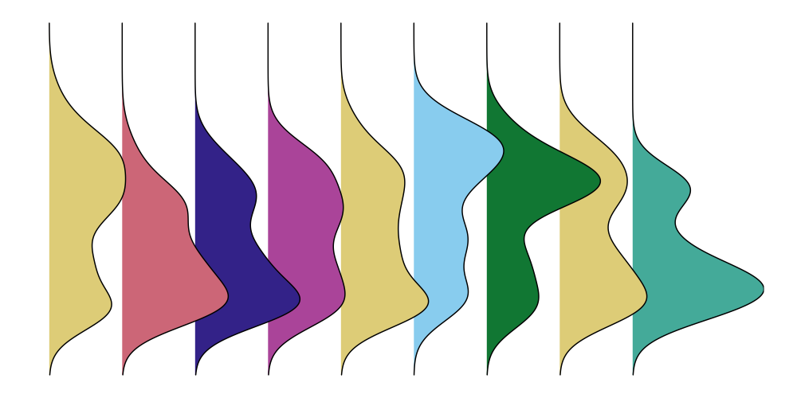

Duration above 250 wake

multiplied

0.061

38m 26s

—

—

—

—

—

—

—

—

—

1.10

1.77

—

—

—

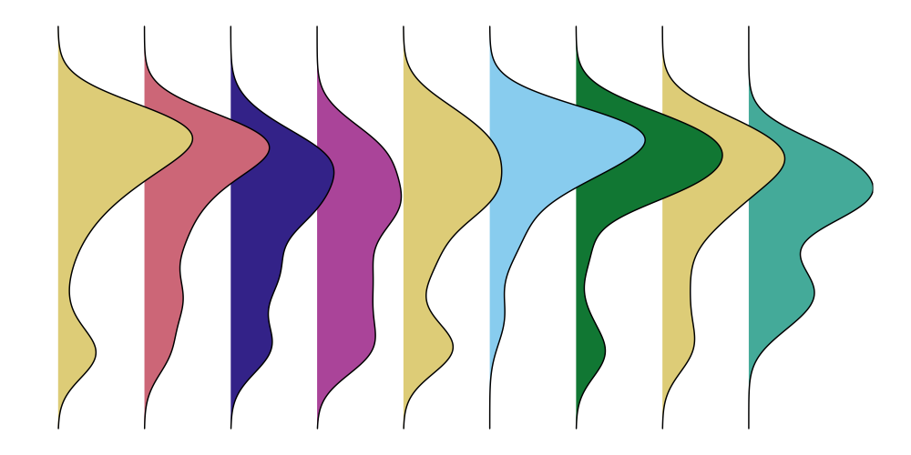

Duration below 10 pre-Sleep

multiplied

>0.9

2h 34m

—

—

—

—

—

—

—

—

—

0.97

1.40

—

—

—

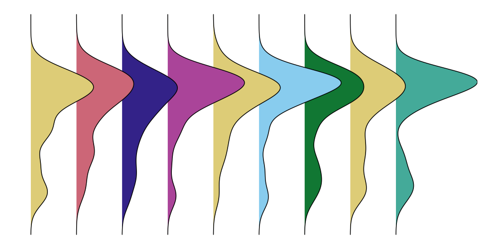

Duration below 1 sleep

multiplied

>0.9

8h 55m

—

—

—

—

—

—

—

—

—

0.98

1.20

—

—

—

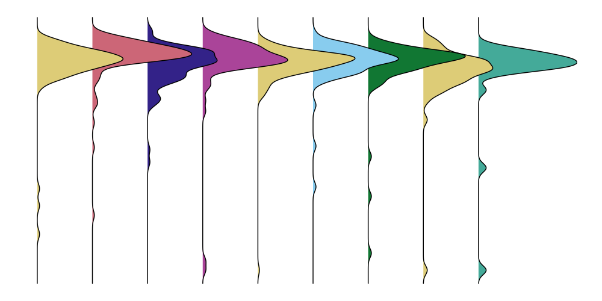

Period above 250

multiplied

>0.9

10m 55s

—

—

—

—

—

—

—

—

—

1.10

1.62

2.12

—

—

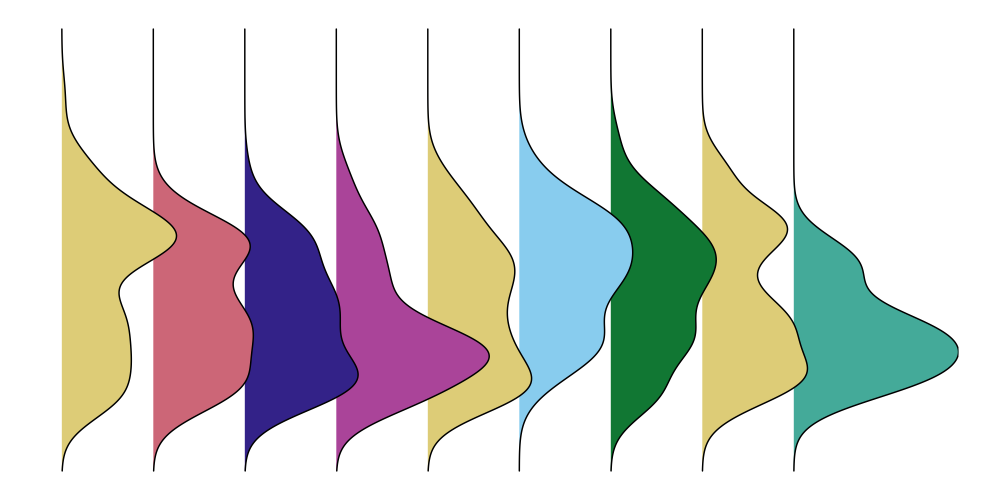

Dynamics<sup>7</sup>

Interdaily stability

logit scale

>0.9

−0.16

—

—

—

—

—

—

—

—

—

−0.04

—

—

—

—

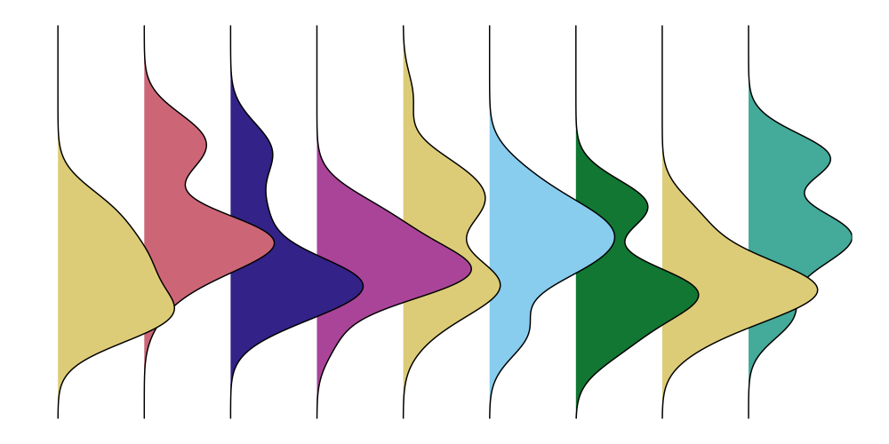

Intradaily variability

additive

>0.9

1.30

—

—

—

—

—

—

—

—

—

0.00

—

—

—

—

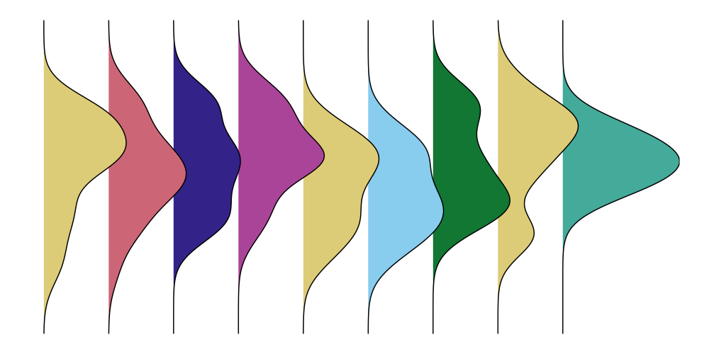

Exposure History

Dose

multiplied

>0.9

358

—

—

—

—

—

—

—

—

—

1.19

2

4

—

—

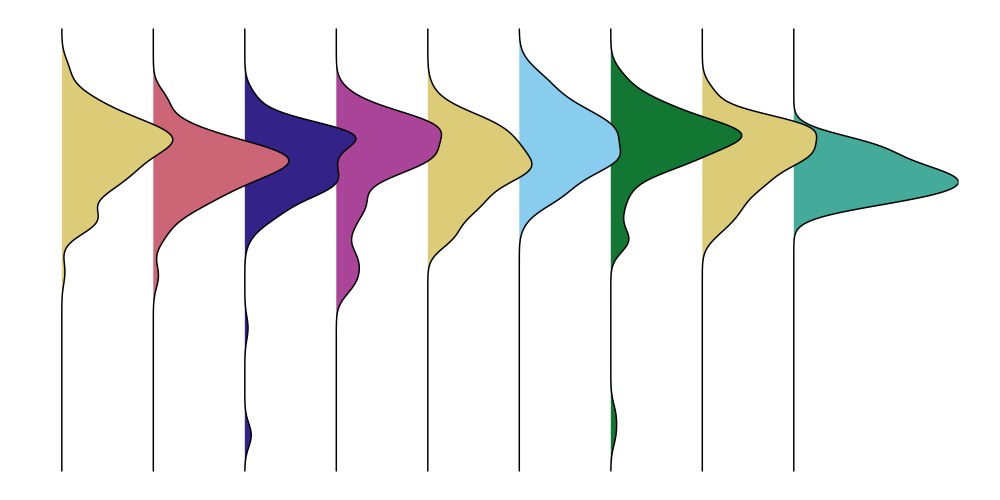

Level

Mean

multiplied

**0.007**

0.41

0.41 (1.00)

0.46 (1.13)

0.60 (1.47)

0.22 (0.54)

0.66 (1.62)

0.47 (1.14)

0.43 (1.05)

0.44 (1.06)

0.51 (1.25)

1.18

1.81

2.02

1.15

1.32

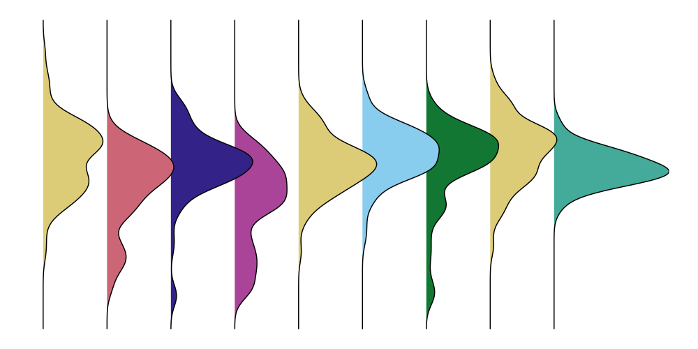

Brightest 10h mean

multiplied

**0.037**

3.92

3.92 (1.00)

5.90 (1.50)

4.50 (1.15)

1.67 (0.43)

6.05 (1.54)

6.08 (1.55)

4.47 (1.14)

2.95 (0.75)

4.19 (1.07)

1.25

2.22

3.18

1.24

—

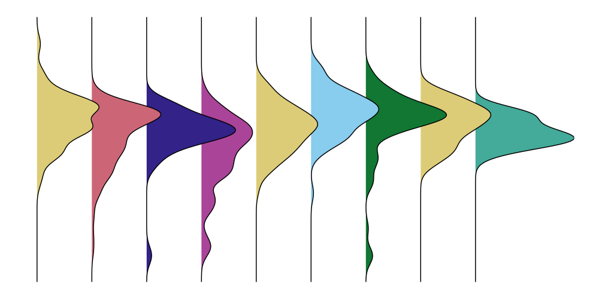

Darkest 10h mean

multiplied

**<0.001**

0.06

0.06 (1.00)

0.05 (0.90)

0.11 (1.78)

0.05 (0.80)

0.10 (1.61)

0.05 (0.88)

0.06 (1.03)

0.10 (1.64)

0.10 (1.71)

1.09

1.63

1.60

—

1.35

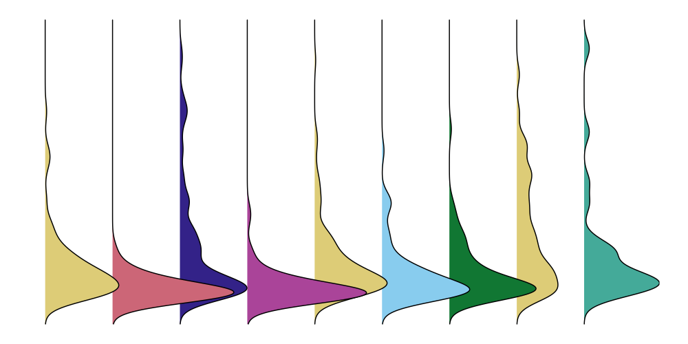

Spectrum

MDER

additive

0.092

0.48

—

—

—

—

—

—

—

—

—

0.02

0.08

0.09

—

—

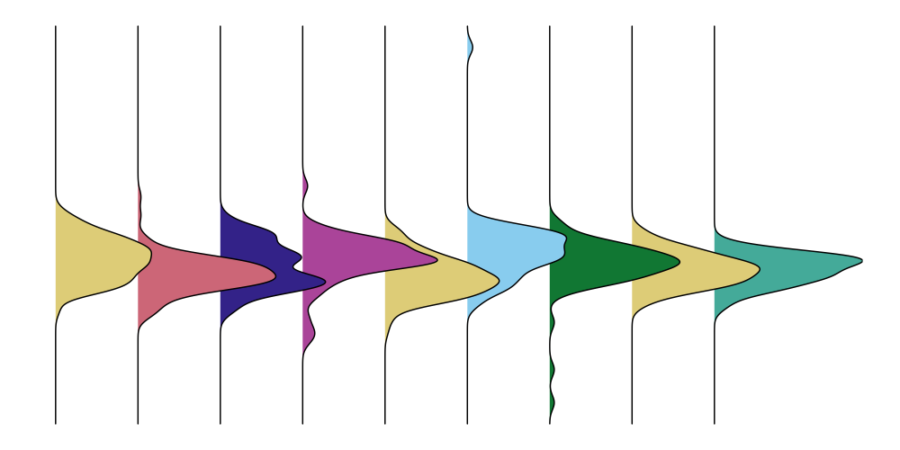

Timing

Brightest 10h midpoint

additive

**0.002**

13:26:52

13:26:52 (0s)

13:52:56 (26m 4s)

13:47:08 (20m 16s)

12:29:48 (−57m 4s)

13:24:47 (−2m 4s)

12:41:48 (−45m 3s)

13:25:10 (−1m 41s)

13:57:23 (30m 30s)

12:07:19 (−1h 19m)

2m 37s

49m 37s

1h 37m

12m 33s

32m 21s

[5 more figures not shown]

<sup>1</sup> Sites have only entries if the (adjusted) p-value is significant, otherwise the results for the null-model are shown. Entries show the site intercept, with the site-specific coefficient below in brackets (relative to the reference level).

<sup>2</sup> *multiplied*: coefficients are multiplicative. This comes from the fact that the models were calculated on a log scale and backtransformed in the table. The Intercept can be read as linear scale, with coefficients being multiplied with the intercept. *additive*: All values are on the linear scale and no transformation is necessary. *logit scale*: data were modelled on the logit scale. Coefficients can be added to the intercept, but have to be transformed with the logistic function.

<sup>3</sup> p-values are adjusted for multiple comparisons using the false-discovery-rate for n= 17 comparisons

<sup>4</sup> These coefficients (*Latitude*) and random effects (*SD Site*) come from two respective separate models that did not contain a fixed effect of site. If the random site or fixed latitude effect is significant, a value is presented. If AIC indicates a significant improvement over the base model (site as fixed effect), it is shown in **bold**. If the base model is significantly stronger, however, values are shown in *grey*.

<sup>5</sup> *Photoperiod*: coefficient per 1-hour change in photoperiod. *Latitude*: coefficient per 10° change in latitude. *SD Site*: random effect standard deviation for site.

<sup>6</sup> Models with a tweedie error distribution do not return a residual standard deviation, as a dispersion parameter is estimated instead during modeling.

<sup>7</sup> Dynamics-based metrics are calculated per participant and thus are using linear/generalized models instead of the mixed-model framework

```r
H1_tab <- H1_table(metrics, H1_fdr_n)
H1_tab
```

```r
gtsave(H1_tab, "tables/H1_phot.png", vwidth = 1700)
```